Saltar al contenido principal

# Comparador de precios: dispositivos de medición y glucometría

Autor/a

Juan Camilo Bonilla Rodríguez

## Introducción

Este trabajo compara los precios de dispositivos de medición y productos de glucometría vendidos en Colombia. La categoría comprende termómetros, tensiómetros, glucómetros, tiras reactivas, lancetas y oxímetros. Se excluyeron las pruebas de embarazo y ovulación. La recolección abarcó las secciones de cada tienda que contienen estos productos; de esa oferta se eligieron ocho presentaciones para comparar.

Los comercios seleccionados fueron **Habib, Farmaprime y Farmaweb**, que tenían las ocho presentaciones disponibles al consultar sus catálogos. Durante la exploración también se recolectaron datos de Locatel, Cafam y La Rebaja, pero no se encontraron suficientes coincidencias con existencias. Esas capturas se conservaron en la base como antecedentes y no se usan en la comparación de precios de este informe.

El objetivo es establecer dónde cuesta menos cada presentación y cuándo un empaque de mayor tamaño reduce el precio por tira o lanceta. Para ello se compararon los precios de las mismas ocho presentaciones en los tres comercios, recogidos durante una sola ejecución.

## Recolección de datos

La extracción está en `scraper.py`. Al ejecutar el documento se procesan las copias guardadas en `raw/`, por lo que se pueden obtener los resultados sin conexión. La opción `TALLER_ONLINE=1` permite volver a consultar las tiendas. El reprocesamiento conserva la fecha original de cada precio y evita insertar observaciones repetidas.

**Código**

```python
import os
import pandas as pd
from IPython.display import display, Markdown
from codigo import db
from scraper import run_all, SCRAPERS
from codigo.consultas import QUERIES, ejecutar, DISPONIBLES
from codigo.validacion import validar_cobertura
from codigo.graficos import grafico_precios, grafico_precio_unitario, grafico_ahorro

resumen = run_all(offline=os.environ.get("TALLER_ONLINE", "0") != "1")
con = db.conectar()
corrida = db.ultima_corrida(con)
assert corrida is not None, "No hay una corrida completa de los tres comercios activos"
control = validar_cobertura(con, corrida)
assert control["cumple_requisito_completo"], "No se alcanzaron ocho presentaciones disponibles en los tres"
display(pd.DataFrame(resumen).T)
display(pd.DataFrame([control]))
fechas = pd.read_sql_query("SELECT MIN(o.fecha_hora) AS inicio_captura,MAX(o.fecha_hora) AS fin_captura FROM observaciones o JOIN ejecuciones e USING(ejecucion_id) WHERE corrida_id=?", con, params=[corrida])
display(Markdown(f"**Corrida:** `{corrida}`. Las fechas y horas corresponden a Colombia."))
display(fechas)
```

```
Habib: obtenidos 102 únicos de 102 reportados por el sitio
Farmaprime: obtenidos 1109 de 1109 reportados
Farmaweb: obtenidos 267 de 267 reportados
Corrida: 2026-11-16T143419384252
             estado     n n_reportado anuncios_nuevos obs_insertadas obs_duplicadas descartes rechazos
comercio4  completa   102         102               0              0             64        38        0
comercio5  completa  1109        1109               0              0             51      1058        0
comercio6  completa   267         267               0              0             24       242        1
```

|  | estado | n | n_reportado | anuncios_nuevos | obs_insertadas | obs_duplicadas | descartes | rechazos |
| --- | --- | --- | --- | --- | --- | --- | --- | --- |
| comercio4 | completa | 102 | 102 | 0 | 0 | 64 | 38 | 0 |
| comercio5 | completa | 1109 | 1109 | 0 | 0 | 51 | 1058 | 0 |
| comercio6 | completa | 267 | 267 | 0 | 0 | 24 | 242 | 1 |

|  | productos_completos | observaciones_comparables_completas | duplicados | valida | productos_disponibles_en_tres | cumple_disponibilidad_minima | cumple_requisito_completo |
| --- | --- | --- | --- | --- | --- | --- | --- |
| 0 | 8 | 24 | [] | True | 8 | True | True |

**Corrida:** `2026-11-16T143419384252`. Las fechas y horas corresponden a Colombia.

|  | inicio_captura | fin_captura |
| --- | --- | --- |
| 0 | 2026-11-16T14:34:21-05:00 | 2026-11-16T14:35:48-05:00 |

La consulta reunió **24 precios: ocho presentaciones en tres comercios**. En los 24 casos, el sitio indicaba disponibilidad. Los productos agotados del resto de la categoría también se guardaron, aunque quedaron fuera de esta selección.

## Fuentes, categorías y scraping

| Comercio | Secciones equivalentes | Extracción |
| --- | --- | --- |
| Habib | Equipos y dispositivos médicos → Equipos de medición, con sus descendientes de glucometría, termómetros y tensiómetros | Catálogo VTEX, filtro jerárquico `/51/176/`, páginas de 50 |
| Farmaprime | Ortopedia y Dispositivos Médicos | API pública WooCommerce Store, categoría 51085, páginas de 100 |
| Farmaweb | Equipamiento Médico y secciones separadas de Termómetros, Termómetros Digitales y Tensiómetros | API pública WooCommerce Store, categorías 26968, 26887, 44978 y 27026, páginas de 100 |

Las direcciones consultadas están en `URLS_COMERCIO4`, `URLS_COMERCIO5` y `URLS_COMERCIO6`, dentro de `scraper.py`. Primero se revisaron las categorías de las tiendas para ubicar los productos. Después se recorrieron sus páginas y se guardaron las respuestas completas. Los 24 precios comparados proceden de esa misma recolección.

En Habib se extrajo la oferta del vendedor principal desde `products[].items[].sellers[].commertialOffer`: `Price` contiene el precio, `ListPrice` el precio de lista y `AvailableQuantity` la cantidad disponible. El encabezado `resources` permitió comprobar el total de productos. En Farmaprime y Farmaweb se usó el servicio público WooCommerce Store: los precios están en `prices` y el total de resultados en `X-WP-Total`. Los valores se convirtieron a COP de acuerdo con `currency_minor_unit`, porque la escala difiere entre tiendas.

Para registrar disponibilidad, Habib debía reportar una cantidad mayor que cero. En Farmaprime y Farmaweb se exigió que el producto estuviera en stock, permitiera la compra y no figurara como pedido pendiente de reposición (`backorder`).

Las peticiones HTTP se hicieron con un agente académico identificable y una pausa de un segundo entre solicitudes. Se fijó un tiempo de espera de 30 segundos, hasta tres intentos por petición y un límite de 60 páginas por sección. El código detecta páginas repetidas. También se revisaron los archivos `robots.txt` y se guardó la página legal de Habib. En las portadas de Farmaprime y Farmaweb no se localizaron enlaces de condiciones; la ruta habitual de términos respondió 404.

### Cobertura de las categorías

**Código**

```python
cobertura=[]
for slug in resumen:
    datos=SCRAPERS[slug](offline=True,corrida_id=corrida)
    for tramo in datos.attrs["cobertura"]:
        cobertura.append({"comercio":datos.comercio.iloc[0],**tramo})
display(pd.DataFrame(cobertura))
```

```
Habib: obtenidos 102 únicos de 102 reportados por el sitio
Farmaprime: obtenidos 1109 de 1109 reportados
Farmaweb: obtenidos 267 de 267 reportados
```

|  | comercio | url | obtenidos | reportado |
| --- | --- | --- | --- | --- |
| 0 | Habib | https://www.habibdroguerias.com/api/catalog_sy... | 102 | 102 |
| 1 | Farmaprime | https://farmaprime.com.co/wp-json/wc/store/v1/... | 1109 | 1109 |
| 2 | Farmaweb | https://farmawebonline.com/wp-json/wc/store/v1... | 253 | 253 |
| 3 | Farmaweb | https://farmawebonline.com/wp-json/wc/store/v1... | 4 | 4 |
| 4 | Farmaweb | https://farmawebonline.com/wp-json/wc/store/v1... | 2 | 2 |
| 5 | Farmaweb | https://farmawebonline.com/wp-json/wc/store/v1... | 8 | 8 |

Los conteos de la tabla corresponden a los anuncios recuperados antes de la limpieza. Por eso son mayores que el número de productos incluidos en el análisis: la sección de Farmaprime, por ejemplo, contiene numerosos insumos ortopédicos ajenos a la categoría. En Farmaweb fue necesario consultar por separado termómetros y tensiómetros, pues no todos estaban dentro de Equipamiento Médico. La primera captura de esa tienda quedó parcial y se conservó en el historial.

## Limpieza y correspondencia

La limpieza se realizó en `codigo/limpieza.py`, manteniendo los textos originales en campos separados. Se unificaron nombres de marcas y unidades, se identificó el contenido de los empaques y se clasificaron los productos. Se descartaron accesorios, pruebas ajenas a la categoría, sensores continuos y suscripciones. La revisión del nombre evitó incluir tiras adhesivas o sábanas en tira entre las tiras reactivas. Los datos que no pudieron identificarse se dejaron como ausentes.

**Código**

```python
from codigo.correspondencia import validar_correspondencia
mapeo=pd.read_csv("datos/correspondencia.csv",dtype={"sku":str})
display(mapeo)
assert validar_correspondencia(con).empty
```

|  | producto_id | nombre_std | marca_std | subcategoria_std | contenido | unidad | n_unidades | concentracion | comercio | sku |
| --- | --- | --- | --- | --- | --- | --- | --- | --- | --- | --- |
| 0 | 6 | Glucoquick G30A · kit 50 tiras + 50 lancetas +... | glucoquick | glucometro | 1 | unidad | 1 | NaN | Habib | 2459 |
| 1 | 6 | Glucoquick G30A · kit 50 tiras + 50 lancetas +... | glucoquick | glucometro | 1 | unidad | 1 | NaN | Farmaprime | 9414 |
| 2 | 6 | Glucoquick G30A · kit 50 tiras + 50 lancetas +... | glucoquick | glucometro | 1 | unidad | 1 | NaN | Farmaweb | 39186 |
| 3 | 10 | Glucoquick G30A · 50 tiras | glucoquick | tiras_reactivas | 50 | unidad | 1 | NaN | Habib | 2437 |
| 4 | 10 | Glucoquick G30A · 50 tiras | glucoquick | tiras_reactivas | 50 | unidad | 1 | NaN | Farmaprime | 9416 |
| 5 | 10 | Glucoquick G30A · 50 tiras | glucoquick | tiras_reactivas | 50 | unidad | 1 | NaN | Farmaweb | 91933 |
| 6 | 11 | Glucoquick G30A · 3 cajas de 50 tiras | glucoquick | tiras_reactivas | 50 | unidad | 3 | NaN | Habib | 2445 |
| 7 | 11 | Glucoquick G30A · 3 cajas de 50 tiras | glucoquick | tiras_reactivas | 50 | unidad | 3 | NaN | Farmaprime | 9420 |
| 8 | 11 | Glucoquick G30A · 3 cajas de 50 tiras | glucoquick | tiras_reactivas | 50 | unidad | 3 | NaN | Farmaweb | 91929 |
| 9 | 12 | Glucoquick G30A · kit 50 tiras + 50 lancetas | glucoquick | tiras_reactivas | 1 | unidad | 1 | NaN | Habib | 2444 |
| 10 | 12 | Glucoquick G30A · kit 50 tiras + 50 lancetas | glucoquick | tiras_reactivas | 1 | unidad | 1 | NaN | Farmaprime | 9421 |
| 11 | 12 | Glucoquick G30A · kit 50 tiras + 50 lancetas | glucoquick | tiras_reactivas | 1 | unidad | 1 | NaN | Farmaweb | 91937 |
| 12 | 13 | Glucoquick · 50 lancetas estériles | glucoquick | lancetas | 50 | unidad | 1 | NaN | Habib | 2461 |
| 13 | 13 | Glucoquick · 50 lancetas estériles | glucoquick | lancetas | 50 | unidad | 1 | NaN | Farmaprime | 6923 |
| 14 | 13 | Glucoquick · 50 lancetas estériles | glucoquick | lancetas | 50 | unidad | 1 | NaN | Farmaweb | 39430 |
| 15 | 14 | Mediclas · 25 tiras reactivas | mediclas | tiras_reactivas | 25 | unidad | 1 | NaN | Habib | 4920 |
| 16 | 14 | Mediclas · 25 tiras reactivas | mediclas | tiras_reactivas | 25 | unidad | 1 | NaN | Farmaprime | 9415 |
| 17 | 14 | Mediclas · 25 tiras reactivas | mediclas | tiras_reactivas | 25 | unidad | 1 | NaN | Farmaweb | 35599 |
| 18 | 15 | Mediclas · 50 tiras reactivas | mediclas | tiras_reactivas | 50 | unidad | 1 | NaN | Habib | 4919 |
| 19 | 15 | Mediclas · 50 tiras reactivas | mediclas | tiras_reactivas | 50 | unidad | 1 | NaN | Farmaprime | 9417 |
| 20 | 15 | Mediclas · 50 tiras reactivas | mediclas | tiras_reactivas | 50 | unidad | 1 | NaN | Farmaweb | 41174 |
| 21 | 16 | Mediclas · 100 lancetas estériles | mediclas | lancetas | 100 | unidad | 1 | NaN | Habib | 5092 |
| 22 | 16 | Mediclas · 100 lancetas estériles | mediclas | lancetas | 100 | unidad | 1 | NaN | Farmaprime | 6922 |
| 23 | 16 | Mediclas · 100 lancetas estériles | mediclas | lancetas | 100 | unidad | 1 | NaN | Farmaweb | 38772 |

Las correspondencias se revisaron con el nombre, la marca, el modelo, la cantidad y los códigos de cada producto. Farmaprime publica códigos de barras en la descripción; Farmaweb utiliza referencias de proveedor que también aparecen en el catálogo de Habib. Las fotografías ayudaron a comprobar los componentes de los kits. Habib, además, publica códigos internos de seis dígitos en el campo `ean`; estos se conservaron tal como estaban y se distinguieron de los códigos de barras del fabricante. El detalle de las ocho correspondencias está en `documentacion/revision_correspondencia.md`.

Cada kit se tomó como un empaque completo, de modo que su precio por unidad corresponde al kit. Para comparar tamaños se agruparon las tiras G30A de 50 y 150 unidades, y las tiras Mediclas de 25 y 50. Los cálculos se hicieron dentro de cada grupo, manteniendo separados los kits y las lancetas.

Los archivos de `raw/manifiestos/` indican qué comercios y qué tabla de correspondencias se usaron en cada ejecución. La tabla `cohortes_comparables` guarda los productos seleccionados en cada captura. Así se puede reconstruir la comparación original aunque después cambien las fuentes.

## Base de datos SQLite

**Código**

```python
display(pd.read_sql_query("SELECT name,type FROM sqlite_master WHERE type IN ('table','view') ORDER BY type,name",con))
display(pd.read_sql_query("SELECT e.corrida_id,c.nombre,e.n_registros,e.estado FROM ejecuciones e JOIN comercios c USING(comercio_id) ORDER BY e.corrida_id,c.nombre",con))
assert con.execute("PRAGMA integrity_check").fetchone()[0]=="ok"
assert not con.execute("PRAGMA foreign_key_check").fetchall()
```

|  | name | type |
| --- | --- | --- |
| 0 | anuncios | table |
| 1 | cohortes_comparables | table |
| 2 | comercios | table |
| 3 | correcciones | table |
| 4 | descartes | table |
| 5 | ejecuciones | table |
| 6 | familias_unidad | table |
| 7 | observaciones | table |
| 8 | productos | table |
| 9 | rechazos | table |
| 10 | v_cambios_precio | view |
| 11 | v_comparables | view |
| 12 | v_observaciones | view |
| 13 | v_promociones | view |
| 14 | v_ultimo_precio | view |

|  | corrida_id | nombre | n_registros | estado |
| --- | --- | --- | --- | --- |
| 0 | 2026-11-16T091137664315 | Cafam | 99 | completa |
| 1 | 2026-11-16T091137664315 | La Rebaja | 59 | completa |
| 2 | 2026-11-16T091137664315 | Locatel | 105 | parcial |
| 3 | 2026-11-16T091502434687 | Cafam | 99 | completa |
| 4 | 2026-11-16T091502434687 | La Rebaja | 59 | completa |
| 5 | 2026-11-16T091502434687 | Locatel | 236 | completa |
| 6 | 2026-11-16T143140453498 | Farmaprime | 1109 | completa |
| 7 | 2026-11-16T143140453498 | Farmaweb | 253 | parcial |
| 8 | 2026-11-16T143140453498 | Habib | 102 | completa |
| 9 | 2026-11-16T143419384252 | Farmaprime | 1109 | completa |
| 10 | 2026-11-16T143419384252 | Farmaweb | 267 | completa |
| 11 | 2026-11-16T143419384252 | Habib | 102 | completa |

La base relaciona cada anuncio con su comercio y cada precio con el anuncio y la ejecución en que fue consultado. Las restricciones de unicidad impiden insertar dos veces la misma observación. Las tablas `correcciones`, `descartes` y `rechazos` registran los cambios de clasificación y los datos que no se pudieron usar. Cada precio conserva el texto de la captura y la ruta de su respuesta original (`raw_ref`). Las 279 observaciones de la exploración inicial siguen en la base.

**Código**

```python
display(pd.read_sql_query("SELECT comercio,COUNT(*) AS observaciones,SUM(descuento_verificable) AS descuentos_numericos,SUM(promocion_anunciada) AS promociones_anunciadas FROM v_promociones WHERE corrida_id=? GROUP BY comercio",con,params=[corrida]))
```

|  | comercio | observaciones | descuentos_numericos | promociones_anunciadas |
| --- | --- | --- | --- | --- |
| 0 | Farmaprime | 51 | 7 | 10 |
| 1 | Farmaweb | 24 | 19 | 20 |
| 2 | Habib | 64 | 60 | 60 |

Se distinguieron los descuentos de precio de las promociones anunciadas. Una oferta «pague dos, lleve tres», por ejemplo, puede aparecer sin un precio de lista mayor. En ese caso se registró el anuncio de la promoción, pero no se le asignó un porcentaje de descuento.

## Consultas SQL

Las siguientes consultas responden las ocho preguntas del análisis. Salvo los conteos del historial, los resultados corresponden a la ejecución indicada al comienzo del informe. Cada comparación usa las mismas presentaciones en los tres comercios.

Pregunta 1

```
SELECT 'TOTAL' AS comercio,
 (SELECT COUNT(*) FROM comercios) AS n_comercios,
 (SELECT COUNT(*) FROM productos) AS presentaciones_identificadas,
 (SELECT COUNT(*) FROM anuncios) AS anuncios_categoria,
 (SELECT COUNT(*) FROM observaciones) AS observaciones
 UNION ALL
 SELECT c.nombre,1,COUNT(DISTINCT a.producto_id),COUNT(DISTINCT a.anuncio_id),COUNT(o.obs_id)
 FROM comercios c LEFT JOIN anuncios a USING(comercio_id)
 LEFT JOIN observaciones o USING(anuncio_id) GROUP BY c.comercio_id
```

|  | comercio | n_comercios | presentaciones_identificadas | anuncios_categoria | observaciones |
| --- | --- | --- | --- | --- | --- |
| 0 | TOTAL | 6 | 16 | 282 | 544 |
| 1 | Locatel | 1 | 9 | 73 | 141 |
| 2 | Cafam | 1 | 9 | 24 | 48 |
| 3 | La Rebaja | 1 | 9 | 45 | 90 |
| 4 | Habib | 1 | 8 | 64 | 128 |
| 5 | Farmaprime | 1 | 8 | 51 | 102 |
| 6 | Farmaweb | 1 | 8 | 25 | 35 |

La base contiene 544 observaciones, 282 anuncios y 16 identidades de productos comparables. Los seis comercios corresponden al historial completo; la comparación actual usa tres y reúne ocho presentaciones.

Pregunta 2

```
WITH grupos AS (SELECT producto_id,comercio_id,COUNT(*) AS n
 FROM v_comparables WHERE corrida_id=:corrida_id AND precio>0
 GROUP BY producto_id,comercio_id), completos AS (
 SELECT producto_id FROM grupos GROUP BY producto_id HAVING COUNT(*)=3 AND SUM(n)=3),
 disponibles AS (SELECT v.producto_id FROM v_comparables v JOIN observaciones o
 ON o.anuncio_id=v.anuncio_id AND o.ejecucion_id=v.ejecucion_id
 WHERE v.corrida_id=:corrida_id AND v.precio>0 AND o.disponibilidad='disponible'
 GROUP BY v.producto_id HAVING COUNT(*)=3 AND COUNT(DISTINCT v.comercio_id)=3)
 SELECT :corrida_id AS corrida_id,
 (SELECT COUNT(*) FROM completos) AS productos_con_tres_comercios,
 (SELECT COUNT(*)*3 FROM completos) AS observaciones_cobertura_completa,
 (SELECT COUNT(*) FROM grupos WHERE n>1) AS pares_duplicados,
 CASE WHEN (SELECT COUNT(*) FROM completos)>=8 AND NOT EXISTS(SELECT 1 FROM grupos WHERE n>1)
 THEN 'CUMPLE' ELSE 'NO CUMPLE' END AS cobertura_precios,
 (SELECT COUNT(*) FROM disponibles) AS productos_disponibles_en_tres,
 CASE WHEN (SELECT COUNT(*) FROM disponibles)>=8 THEN 'CUMPLE' ELSE 'NO CUMPLE' END AS disponibilidad_minima
```

|  | corrida_id | productos_con_tres_comercios | observaciones_cobertura_completa | pares_duplicados | cobertura_precios | productos_disponibles_en_tres | disponibilidad_minima |
| --- | --- | --- | --- | --- | --- | --- | --- |
| 0 | 2026-11-16T143419384252 | 8 | 24 | 0 | CUMPLE | 8 | CUMPLE |

Las ocho presentaciones tienen precio y existencias en los tres comercios. Se obtuvieron 24 observaciones, sin repetir ningún par producto–comercio.

Pregunta 3

```
WITH base AS (
 SELECT * FROM v_comparables WHERE corrida_id=:corrida_id AND precio>0),
 completos AS (SELECT producto_id FROM base GROUP BY producto_id
 HAVING COUNT(DISTINCT comercio_id)=3 AND COUNT(*)=3),
 precios AS (SELECT b.* FROM base b JOIN completos USING(producto_id)),
 resumen AS (SELECT producto_id, MAX(producto_nombre) AS producto,
 MIN(precio) AS minimo, MAX(precio) AS maximo, AVG(precio) AS promedio
 FROM precios GROUP BY producto_id) SELECT r.*, GROUP_CONCAT(p.comercio, ' / ') AS comercios_menor_precio
 FROM resumen r JOIN precios p ON p.producto_id=r.producto_id AND p.precio=r.minimo
 GROUP BY r.producto_id ORDER BY r.producto_id
```

|  | producto_id | producto | minimo | maximo | promedio | comercios_menor_precio |
| --- | --- | --- | --- | --- | --- | --- |
| 0 | 6 | Glucoquick G30A · kit 50 tiras + 50 lancetas +... | 105000.0 | 109800.0 | 107000.000000 | Farmaweb |
| 1 | 10 | Glucoquick G30A · 50 tiras | 104700.0 | 106200.0 | 105300.000000 | Habib |
| 2 | 11 | Glucoquick G30A · 3 cajas de 50 tiras | 196500.0 | 210300.0 | 204333.333333 | Habib |
| 3 | 12 | Glucoquick G30A · kit 50 tiras + 50 lancetas | 100700.0 | 106200.0 | 103966.666667 | Habib |
| 4 | 13 | Glucoquick · 50 lancetas estériles | 20300.0 | 21800.0 | 20900.000000 | Habib |
| 5 | 14 | Mediclas · 25 tiras reactivas | 50200.0 | 62700.0 | 58500.000000 | Habib |
| 6 | 15 | Mediclas · 50 tiras reactivas | 98500.0 | 100200.0 | 99600.000000 | Habib |
| 7 | 16 | Mediclas · 100 lancetas estériles | 49800.0 | 54000.0 | 52400.000000 | Farmaprime |

Habib presenta el menor precio en seis productos, Farmaweb en uno y Farmaprime en otro. No hubo empates en esta captura. El promedio resume los tres precios de cada presentación.

Pregunta 4

```
WITH base AS (
 SELECT * FROM v_comparables WHERE corrida_id=:corrida_id AND precio>0),
 completos AS (SELECT producto_id FROM base GROUP BY producto_id
 HAVING COUNT(DISTINCT comercio_id)=3 AND COUNT(*)=3),
 precios AS (SELECT b.* FROM base b JOIN completos USING(producto_id)),
 resumen AS (SELECT producto_id, MAX(producto_nombre) AS producto,
 MIN(precio) AS minimo, MAX(precio) AS maximo, AVG(precio) AS promedio
 FROM precios GROUP BY producto_id) SELECT producto_id,producto,minimo,maximo,maximo-minimo AS ahorro_cop,
 ROUND(100.0*(maximo-minimo)/NULLIF(maximo,0),2) AS ahorro_pct
 FROM resumen ORDER BY producto_id
```

|  | producto_id | producto | minimo | maximo | ahorro_cop | ahorro_pct |
| --- | --- | --- | --- | --- | --- | --- |
| 0 | 6 | Glucoquick G30A · kit 50 tiras + 50 lancetas +... | 105000.0 | 109800.0 | 4800.0 | 4.37 |
| 1 | 10 | Glucoquick G30A · 50 tiras | 104700.0 | 106200.0 | 1500.0 | 1.41 |
| 2 | 11 | Glucoquick G30A · 3 cajas de 50 tiras | 196500.0 | 210300.0 | 13800.0 | 6.56 |
| 3 | 12 | Glucoquick G30A · kit 50 tiras + 50 lancetas | 100700.0 | 106200.0 | 5500.0 | 5.18 |
| 4 | 13 | Glucoquick · 50 lancetas estériles | 20300.0 | 21800.0 | 1500.0 | 6.88 |
| 5 | 14 | Mediclas · 25 tiras reactivas | 50200.0 | 62700.0 | 12500.0 | 19.94 |
| 6 | 15 | Mediclas · 50 tiras reactivas | 98500.0 | 100200.0 | 1700.0 | 1.70 |
| 7 | 16 | Mediclas · 100 lancetas estériles | 49800.0 | 54000.0 | 4200.0 | 7.78 |

El mayor ahorro absoluto es de 13.800 COP en el paquete G30A de 150 tiras. En las 25 tiras Mediclas, la diferencia es de 12.500 COP, equivalente al 19,94 % del precio más alto.

Pregunta 5

```
WITH base AS (
 SELECT v.*, CASE WHEN f.familia IS NOT NULL THEN f.familia WHEN v.subcategoria_std='lancetas' AND v.marca_std='accu-chek'
 AND instr(lower(v.texto_original),'softclix')>0
 THEN 'Accu-Chek Softclix (misma lanceta, tamaños distintos)' ELSE p.nombre_std END AS grupo
 FROM v_observaciones v LEFT JOIN productos p USING(producto_id) LEFT JOIN familias_unidad f USING(producto_id)
 WHERE v.corrida_id=:corrida_id AND v.precio>0 AND v.contenido_total>0
 AND (v.comparable=1 OR (v.subcategoria_std='lancetas' AND v.marca_std='accu-chek'
 AND instr(lower(v.texto_original),'softclix')>0))),
 rangos AS (SELECT *,DENSE_RANK() OVER(
 PARTITION BY marca_std,subcategoria_std,grupo,concentracion,unidad
 ORDER BY precio_por_unidad) AS orden FROM base)
 SELECT producto_id,grupo,sku,titulo_original AS presentacion,comercio,contenido_total,unidad,
 precio AS desembolso_cop,ROUND(precio_por_unidad,2) AS cop_por_unidad
 FROM rangos WHERE orden=1 ORDER BY grupo,unidad,comercio
```

|  | producto_id | grupo | sku | presentacion | comercio | contenido_total | unidad | desembolso_cop | cop_por_unidad |
| --- | --- | --- | --- | --- | --- | --- | --- | --- | --- |
| 0 | 12 | Glucoquick G30A · kit 50 tiras + 50 lancetas | 2444 | Oferta Tiras Glucoquick G30 X50 + Lancetas X 50 | Habib | 1.0 | unidad | 100700.0 | 100700.0 |
| 1 | 6 | Glucoquick G30A · kit 50 tiras + 50 lancetas +... | 39186 | Tiras Glucometrícas 50 Unidades + Glucómetro G... | Farmaweb | 1.0 | unidad | 105000.0 | 105000.0 |
| 2 | 11 | Glucoquick G30A: tiras sin accesorios | 2445 | Oferta Tiras Glucoquick G30 X50 Pague 2 Lleve 3 | Habib | 150.0 | unidad | 196500.0 | 1310.0 |
| 3 | 13 | Glucoquick · 50 lancetas estériles | 2461 | Lancetas Glucoquick Esteriles X 50 Unidades | Habib | 50.0 | unidad | 20300.0 | 406.0 |
| 4 | 16 | Mediclas · 100 lancetas estériles | 6922 | Lancetas Glucometria Mediclas 100 Unidades Icom | Farmaprime | 100.0 | unidad | 49800.0 | 498.0 |
| 5 | 15 | Mediclas: tiras reactivas | 4919 | Tiras Reactivas Glucometro Mediclas 50 Unidades | Habib | 50.0 | unidad | 98500.0 | 1970.0 |

Habib ofrece el menor precio por tira en los dos grupos de tamaños comparados: 1.310 COP en G30A de 150 unidades y 1.970 COP en Mediclas de 50. Los kits y las lancetas se mantienen en grupos separados.

Pregunta 6

```
WITH base AS (
 SELECT * FROM v_comparables WHERE corrida_id=:corrida_id AND precio>0),
 completos AS (SELECT producto_id FROM base GROUP BY producto_id
 HAVING COUNT(DISTINCT comercio_id)=3 AND COUNT(*)=3),
 precios AS (SELECT b.* FROM base b JOIN completos USING(producto_id)),
 resumen AS (SELECT producto_id, MAX(producto_nombre) AS producto,
 MIN(precio) AS minimo, MAX(precio) AS maximo, AVG(precio) AS promedio
 FROM precios GROUP BY producto_id) SELECT producto_id,producto,minimo,maximo,maximo-minimo AS ahorro_cop,
 ROUND(100.0*(maximo-minimo)/NULLIF(maximo,0),2) AS ahorro_pct
 FROM resumen ORDER BY ahorro_pct DESC,producto_id
```

|  | producto_id | producto | minimo | maximo | ahorro_cop | ahorro_pct |
| --- | --- | --- | --- | --- | --- | --- |
| 0 | 14 | Mediclas · 25 tiras reactivas | 50200.0 | 62700.0 | 12500.0 | 19.94 |
| 1 | 16 | Mediclas · 100 lancetas estériles | 49800.0 | 54000.0 | 4200.0 | 7.78 |
| 2 | 13 | Glucoquick · 50 lancetas estériles | 20300.0 | 21800.0 | 1500.0 | 6.88 |
| 3 | 11 | Glucoquick G30A · 3 cajas de 50 tiras | 196500.0 | 210300.0 | 13800.0 | 6.56 |
| 4 | 12 | Glucoquick G30A · kit 50 tiras + 50 lancetas | 100700.0 | 106200.0 | 5500.0 | 5.18 |
| 5 | 6 | Glucoquick G30A · kit 50 tiras + 50 lancetas +... | 105000.0 | 109800.0 | 4800.0 | 4.37 |
| 6 | 15 | Mediclas · 50 tiras reactivas | 98500.0 | 100200.0 | 1700.0 | 1.70 |
| 7 | 10 | Glucoquick G30A · 50 tiras | 104700.0 | 106200.0 | 1500.0 | 1.41 |

Mediclas de 25 tiras encabeza la lista con una diferencia del 19,94 %. En las tiras G30A de 50, la diferencia es de 1.500 COP, un 1,41 % del precio máximo.

Pregunta 7

```
SELECT comercio,COUNT(*) AS observaciones,
 SUM(precio IS NULL OR precio<=0) AS precios_invalidos,
 SUM(marca_std IS NULL OR marca_std='') AS sin_marca,
 SUM(descripcion_original IS NULL OR descripcion_original='') AS sin_descripcion,
 SUM(contenido_total IS NULL OR contenido_total<=0) AS sin_contenido,
 SUM(url IS NULL OR url='') AS sin_url,
 SUM(fecha_hora IS NULL OR fecha_hora NOT LIKE '%-05:00') AS fecha_invalida,
 (SELECT COUNT(*) FROM rechazos r JOIN ejecuciones e USING(ejecucion_id)
 WHERE e.corrida_id=:corrida_id AND e.comercio_id=v.comercio_id) AS precios_rechazados
 FROM v_observaciones v WHERE corrida_id=:corrida_id GROUP BY comercio_id
```

|  | comercio | observaciones | precios_invalidos | sin_marca | sin_descripcion | sin_contenido | sin_url | fecha_invalida | precios_rechazados |
| --- | --- | --- | --- | --- | --- | --- | --- | --- | --- |
| 0 | Habib | 64 | 0 | 0 | 49 | 2 | 0 | 0 | 0 |
| 1 | Farmaprime | 51 | 0 | 1 | 0 | 2 | 0 | 0 | 0 |
| 2 | Farmaweb | 24 | 0 | 10 | 0 | 2 | 0 | 0 | 1 |

Habib tiene 49 observaciones sin descripción. En Farmaprime falta la marca en una y en Farmaweb en diez. Hay dos observaciones sin contenido identificado en cada comercio. Farmaweb aportó además un precio inválido que quedó en rechazos.

Pregunta 8

```
SELECT c.nombre AS comercio,e.corrida_id,e.estado,e.n_registros AS anuncios_extraidos_secciones,
 e.n_reportado_sitio AS total_reportado_secciones,
 COUNT(DISTINCT o.anuncio_id) AS productos_con_precio_valido,
 (SELECT COUNT(*) FROM descartes d WHERE d.ejecucion_id=e.ejecucion_id AND NOT EXISTS(SELECT 1 FROM anuncios ax JOIN observaciones ox USING(anuncio_id) WHERE ax.comercio_id=d.comercio_id AND ax.sku=d.sku AND ox.ejecucion_id=d.ejecucion_id)) AS excluidos,
 (SELECT COUNT(*) FROM rechazos r WHERE r.ejecucion_id=e.ejecucion_id) AS rechazados,
 ROUND(100.0*SUM(a.descripcion_original IS NOT NULL AND a.descripcion_original!='')/NULLIF(COUNT(o.obs_id),0),1) AS pct_descripcion,
 ROUND(100.0*SUM(a.marca_std IS NOT NULL AND a.marca_std!='')/NULLIF(COUNT(o.obs_id),0),1) AS pct_marca,
 ROUND(100.0*SUM(a.contenido*a.n_unidades>0)/NULLIF(COUNT(o.obs_id),0),1) AS pct_contenido
 FROM ejecuciones e JOIN comercios c USING(comercio_id)
 LEFT JOIN observaciones o USING(ejecucion_id) LEFT JOIN anuncios a USING(anuncio_id)
 GROUP BY e.ejecucion_id ORDER BY e.corrida_id,c.nombre
```

|  | comercio | corrida_id | estado | anuncios_extraidos_secciones | total_reportado_secciones | productos_con_precio_valido | excluidos | rechazados | pct_descripcion | pct_marca | pct_contenido |
| --- | --- | --- | --- | --- | --- | --- | --- | --- | --- | --- | --- |
| 0 | Cafam | 2026-11-16T091137664315 | completa | 99 | 99 | 24 | 75 | 0 | 0.0 | 100.0 | 100.0 |
| 1 | La Rebaja | 2026-11-16T091137664315 | completa | 59 | 59 | 45 | 14 | 0 | 100.0 | 100.0 | 88.9 |
| 2 | Locatel | 2026-11-16T091137664315 | parcial | 105 | 105 | 69 | 36 | 0 | 100.0 | 100.0 | 89.9 |
| 3 | Cafam | 2026-11-16T091502434687 | completa | 99 | 99 | 24 | 75 | 0 | 0.0 | 100.0 | 100.0 |
| 4 | La Rebaja | 2026-11-16T091502434687 | completa | 59 | 59 | 45 | 14 | 0 | 100.0 | 100.0 | 88.9 |
| 5 | Locatel | 2026-11-16T091502434687 | completa | 236 | 236 | 72 | 163 | 1 | 100.0 | 100.0 | 88.9 |
| 6 | Farmaprime | 2026-11-16T143140453498 | completa | 1109 | 1109 | 51 | 1058 | 0 | 100.0 | 98.0 | 96.1 |
| 7 | Farmaweb | 2026-11-16T143140453498 | parcial | 253 | 253 | 11 | 242 | 0 | 100.0 | 81.8 | 81.8 |
| 8 | Habib | 2026-11-16T143140453498 | completa | 102 | 102 | 64 | 38 | 0 | 23.4 | 100.0 | 96.9 |
| 9 | Farmaprime | 2026-11-16T143419384252 | completa | 1109 | 1109 | 51 | 1058 | 0 | 100.0 | 98.0 | 96.1 |
| 10 | Farmaweb | 2026-11-16T143419384252 | completa | 267 | 267 | 24 | 242 | 1 | 100.0 | 58.3 | 91.7 |
| 11 | Habib | 2026-11-16T143419384252 | completa | 102 | 102 | 64 | 38 | 0 | 23.4 | 100.0 | 96.9 |

Habib aportó 64 productos con precio válido, Farmaprime 51 y Farmaweb 24 en la captura completa. El mayor número de anuncios inicialmente extraídos de Farmaprime se explica por la amplitud de su sección de ortopedia. Los porcentajes se calculan sobre los productos con precio válido.

## Disponibilidad y recomendación por presentación

**Código**

```python
ofertas=pd.read_sql_query(DISPONIBLES,con,params={"corrida_id":corrida})
assert len(ofertas)==24 and ofertas.disponibilidad.eq("disponible").all()
display(ofertas)
display(ofertas.loc[ofertas.mejor_disponible==1,["producto","comercio","precio_anunciado_cop","disponibilidad"]])
```

|  | producto_id | producto | comercio | precio_anunciado_cop | disponibilidad | minimo_disponible_cop | mejor_disponible |
| --- | --- | --- | --- | --- | --- | --- | --- |
| 0 | 6 | Glucoquick G30A · kit 50 tiras + 50 lancetas +... | Farmaprime | 106200.0 | disponible | 105000.0 | 0 |
| 1 | 6 | Glucoquick G30A · kit 50 tiras + 50 lancetas +... | Farmaweb | 105000.0 | disponible | 105000.0 | 1 |
| 2 | 6 | Glucoquick G30A · kit 50 tiras + 50 lancetas +... | Habib | 109800.0 | disponible | 105000.0 | 0 |
| 3 | 10 | Glucoquick G30A · 50 tiras | Farmaprime | 106200.0 | disponible | 104700.0 | 0 |
| 4 | 10 | Glucoquick G30A · 50 tiras | Farmaweb | 105000.0 | disponible | 104700.0 | 0 |
| 5 | 10 | Glucoquick G30A · 50 tiras | Habib | 104700.0 | disponible | 104700.0 | 1 |
| 6 | 11 | Glucoquick G30A · 3 cajas de 50 tiras | Farmaprime | 206200.0 | disponible | 196500.0 | 0 |
| 7 | 11 | Glucoquick G30A · 3 cajas de 50 tiras | Farmaweb | 210300.0 | disponible | 196500.0 | 0 |
| 8 | 11 | Glucoquick G30A · 3 cajas de 50 tiras | Habib | 196500.0 | disponible | 196500.0 | 1 |
| 9 | 12 | Glucoquick G30A · kit 50 tiras + 50 lancetas | Farmaprime | 106200.0 | disponible | 100700.0 | 0 |
| 10 | 12 | Glucoquick G30A · kit 50 tiras + 50 lancetas | Farmaweb | 105000.0 | disponible | 100700.0 | 0 |
| 11 | 12 | Glucoquick G30A · kit 50 tiras + 50 lancetas | Habib | 100700.0 | disponible | 100700.0 | 1 |
| 12 | 13 | Glucoquick · 50 lancetas estériles | Farmaprime | 21800.0 | disponible | 20300.0 | 0 |
| 13 | 13 | Glucoquick · 50 lancetas estériles | Farmaweb | 20600.0 | disponible | 20300.0 | 0 |
| 14 | 13 | Glucoquick · 50 lancetas estériles | Habib | 20300.0 | disponible | 20300.0 | 1 |
| 15 | 14 | Mediclas · 25 tiras reactivas | Farmaprime | 62600.0 | disponible | 50200.0 | 0 |
| 16 | 14 | Mediclas · 25 tiras reactivas | Farmaweb | 62700.0 | disponible | 50200.0 | 0 |
| 17 | 14 | Mediclas · 25 tiras reactivas | Habib | 50200.0 | disponible | 50200.0 | 1 |
| 18 | 15 | Mediclas · 50 tiras reactivas | Farmaprime | 100100.0 | disponible | 98500.0 | 0 |
| 19 | 15 | Mediclas · 50 tiras reactivas | Farmaweb | 100200.0 | disponible | 98500.0 | 0 |
| 20 | 15 | Mediclas · 50 tiras reactivas | Habib | 98500.0 | disponible | 98500.0 | 1 |
| 21 | 16 | Mediclas · 100 lancetas estériles | Farmaprime | 49800.0 | disponible | 49800.0 | 1 |
| 22 | 16 | Mediclas · 100 lancetas estériles | Farmaweb | 53400.0 | disponible | 49800.0 | 0 |
| 23 | 16 | Mediclas · 100 lancetas estériles | Habib | 54000.0 | disponible | 49800.0 | 0 |

|  | producto | comercio | precio_anunciado_cop | disponibilidad |
| --- | --- | --- | --- | --- |
| 1 | Glucoquick G30A · kit 50 tiras + 50 lancetas +... | Farmaweb | 105000.0 | disponible |
| 5 | Glucoquick G30A · 50 tiras | Habib | 104700.0 | disponible |
| 8 | Glucoquick G30A · 3 cajas de 50 tiras | Habib | 196500.0 | disponible |
| 11 | Glucoquick G30A · kit 50 tiras + 50 lancetas | Habib | 100700.0 | disponible |
| 14 | Glucoquick · 50 lancetas estériles | Habib | 20300.0 | disponible |
| 17 | Mediclas · 25 tiras reactivas | Habib | 50200.0 | disponible |
| 20 | Mediclas · 50 tiras reactivas | Habib | 98500.0 | disponible |
| 21 | Mediclas · 100 lancetas estériles | Farmaprime | 49800.0 | disponible |

Habib tuvo el menor precio en seis de las ocho presentaciones. Farmaweb ofreció el kit G30A con glucómetro más económico, mientras que Farmaprime tuvo el menor precio de las 100 lancetas Mediclas. Esta comparación corresponde al precio anunciado del producto; el envío puede cambiar el total de la compra.

## Gráficos e interpretación

**Código**

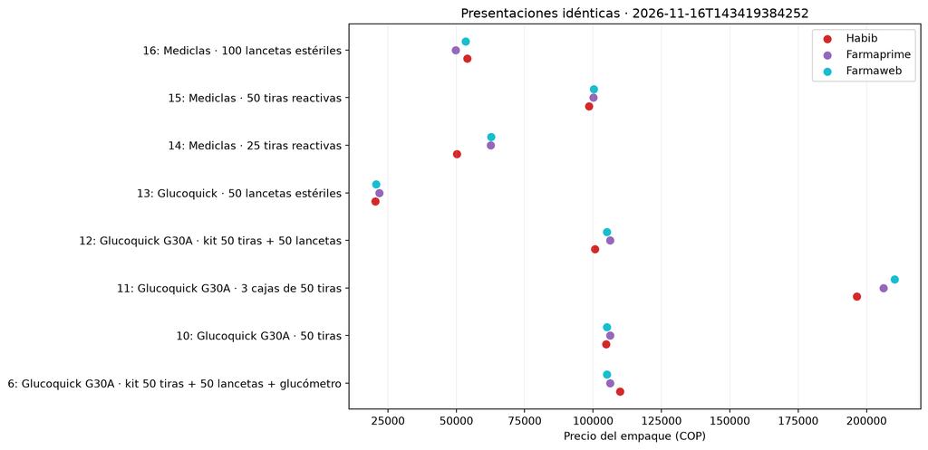

```python
display(grafico_precios(con,corrida))
```

Las diferencias más amplias se observan en las tiras Mediclas de 25 unidades y en el paquete G30A de 150. Los precios de las tiras G30A de 50, en cambio, son cercanos entre los tres comercios.

**Código**

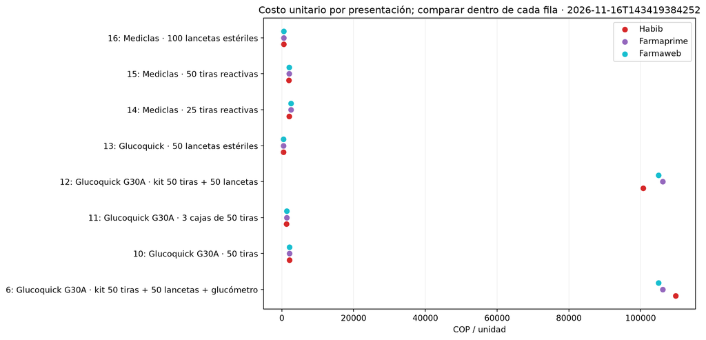

```python
display(grafico_precio_unitario(con,corrida))
```

El precio unitario permite comparar ofertas del mismo producto dentro de cada fila. En las tiras y lancetas se expresa por artículo; en los kits, por empaque completo. La comparación entre tamaños de tiras se presenta más adelante.

**Código**

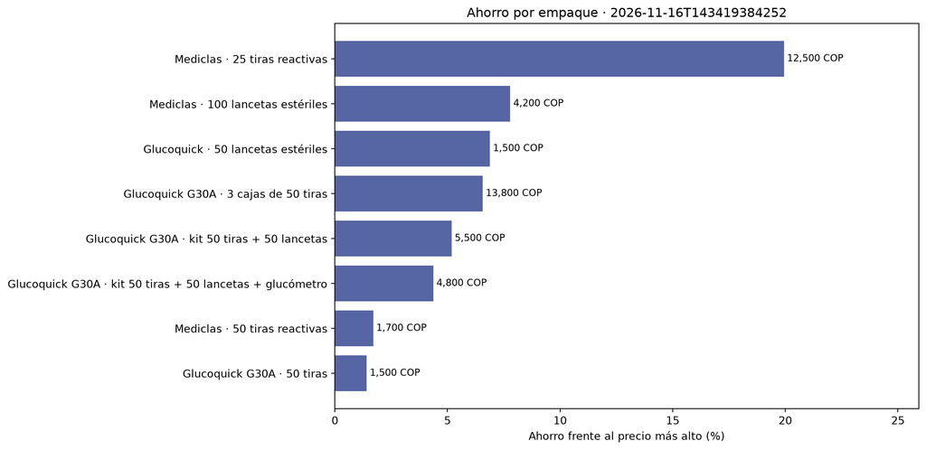

La mayor diferencia porcentual corresponde a **Mediclas · 25 tiras reactivas**: 12,500 COP, equivalentes al 19.94 % del precio máximo de esa presentación.

```python
display(grafico_ahorro(con,corrida))
ahorros=ejecutar(6,con,corrida)
mayor=ahorros.iloc[0]
display(Markdown(f"La mayor diferencia porcentual corresponde a **{mayor.producto}**: {mayor.ahorro_cop:,.0f} COP, equivalentes al {mayor.ahorro_pct:.2f} % del precio máximo de esa presentación."))
```

La diferencia porcentual ayuda a identificar dónde vale la pena comparar comercios. La diferencia en COP muestra cuánto se ahorraría al comprar un empaque de esa presentación.

**Código**

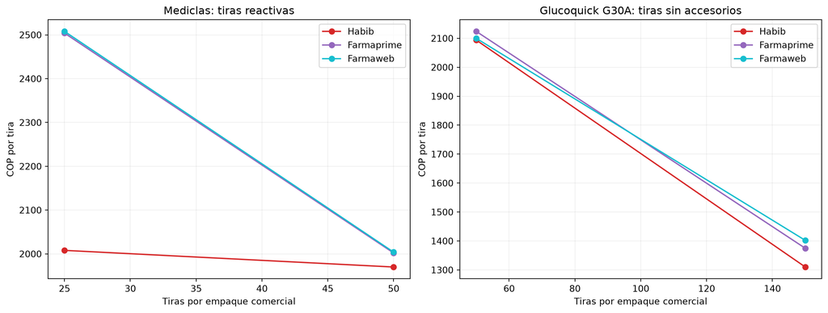

|  | producto_nombre | familia | comercio | contenido_total | precio | precio_por_unidad |
| --- | --- | --- | --- | --- | --- | --- |
| 6 | Glucoquick G30A · 50 tiras | Glucoquick G30A: tiras sin accesorios | Farmaprime | 50.0 | 106200.0 | 2124.000000 |
| 8 | Glucoquick G30A · 50 tiras | Glucoquick G30A: tiras sin accesorios | Farmaweb | 50.0 | 105000.0 | 2100.000000 |
| 3 | Glucoquick G30A · 50 tiras | Glucoquick G30A: tiras sin accesorios | Habib | 50.0 | 104700.0 | 2094.000000 |
| 4 | Glucoquick G30A · 3 cajas de 50 tiras | Glucoquick G30A: tiras sin accesorios | Farmaprime | 150.0 | 206200.0 | 1374.666667 |
| 9 | Glucoquick G30A · 3 cajas de 50 tiras | Glucoquick G30A: tiras sin accesorios | Farmaweb | 150.0 | 210300.0 | 1402.000000 |
| 2 | Glucoquick G30A · 3 cajas de 50 tiras | Glucoquick G30A: tiras sin accesorios | Habib | 150.0 | 196500.0 | 1310.000000 |
| 7 | Mediclas · 25 tiras reactivas | Mediclas: tiras reactivas | Farmaprime | 25.0 | 62600.0 | 2504.000000 |
| 11 | Mediclas · 25 tiras reactivas | Mediclas: tiras reactivas | Farmaweb | 25.0 | 62700.0 | 2508.000000 |
| 0 | Mediclas · 25 tiras reactivas | Mediclas: tiras reactivas | Habib | 25.0 | 50200.0 | 2008.000000 |
| 5 | Mediclas · 50 tiras reactivas | Mediclas: tiras reactivas | Farmaprime | 50.0 | 100100.0 | 2002.000000 |
| 10 | Mediclas · 50 tiras reactivas | Mediclas: tiras reactivas | Farmaweb | 50.0 | 100200.0 | 2004.000000 |
| 1 | Mediclas · 50 tiras reactivas | Mediclas: tiras reactivas | Habib | 50.0 | 98500.0 | 1970.000000 |

```python
import matplotlib.pyplot as plt
from codigo.config import COLORES
comparacion=pd.read_sql_query("SELECT v.producto_nombre,f.familia,v.comercio,v.contenido_total,v.precio,v.precio_por_unidad FROM v_comparables v JOIN familias_unidad f USING(producto_id) WHERE v.corrida_id=?",con,params=[corrida])
familias=list(comparacion.familia.unique())
fig,axs=plt.subplots(1,len(familias),figsize=(13,5),squeeze=False)
for ax,familia in zip(axs[0],familias):
    sub=comparacion[comparacion.familia==familia]
    for comercio in sub.comercio.unique():
        s=sub[sub.comercio==comercio].sort_values("contenido_total")
        ax.plot(s.contenido_total,s.precio_por_unidad,"o-",label=comercio,color=COLORES[comercio])
    ax.set_title(familia);ax.set_xlabel("Tiras por empaque comercial");ax.set_ylabel("COP por tira");ax.legend();ax.grid(alpha=.2)
fig.tight_layout();display(fig)
display(comparacion.sort_values(["familia","contenido_total","comercio"]))
```

En Habib, las 150 tiras G30A costaron 196.500 COP, equivalentes a 1.310 COP por tira. El empaque de 50 costó 104.700 COP, o 2.094 COP por tira. Comprar el paquete grande reduce el costo unitario, pero exige pagar 91.800 COP más en esa compra. En Mediclas, pasar de 25 a 50 tiras reduce el precio de 2.008 a 1.970 COP por tira en el mismo comercio. La diferencia entre tamaños es mucho menor en esta línea.

## Limitaciones

Los precios y las existencias corresponden al momento de consulta. El análisis no incluye envío, mínimos de compra ni restricciones de las promociones. La entrega a una dirección concreta y el inventario disponible deben confirmarse al realizar el pedido.

La cobertura depende de cómo cada tienda organiza sus categorías. Algunos anuncios no tienen descripción o marca identificable, y hubo precios que no pudieron utilizarse. También se encontró una inconsistencia en Farmaweb: el anuncio de dos cajas de 25 tiras G30A menciona Mediclas en la descripción. Ese producto se conservó en los datos recolectados, pero quedó fuera de las ocho correspondencias.

Las capturas se realizaron el 16 de noviembre de 2026, por lo que no permiten evaluar cambios de precio entre días. La ejecución se comprobó localmente, tanto en línea como a partir de las copias guardadas; no se probó en otro computador.

## Conclusiones

En la fecha de consulta, Habib fue la opción más económica para las tiras G30A y Mediclas, el kit de 50 tiras G30A con 50 lancetas y las 50 lancetas Glucoquick. Para el kit que incluye glucómetro convino Farmaweb; para las 100 lancetas Mediclas, Farmaprime.

El tamaño del empaque también influyó en el costo. Las 150 tiras G30A tuvieron un precio por tira considerablemente menor que las 50, mientras que la ventaja del empaque Mediclas de 50 frente al de 25 fue pequeña. La elección depende de la cantidad que se necesite y del dinero disponible para la compra. Estas comparaciones se limitan a cada línea de producto y no indican que las tiras de marcas diferentes sean intercambiables.

**Código**

```python
con.close()
```